# Datenvisualisierung mit R

Funktionen

Armin Schäfer

schaefer@politik.uni-mainz.de

12.06.2025

## Vorsicht beim Einsatz von `na.omit()`!

Häufig stören fehlende Werte in einem Datensatz, weil sie unter Umständen in der Grafik dargestellt werden. Es gibt verschiedene Wege damit umzugehen. Eine Möglichkeit ist, die fehlenden Werte mit `na.omit()` zu entfernen. Das ist aber nicht immer sinnvoll, da dadurch ganze Zeilen gelöscht werden, die unter Umständen für andere Variablen noch Daten enthalten.

## Vorsicht beim Einsatz von `na.omit()`!

```r
ces %>%
  na.omit() %>%
  tally()
```

```
      n
1 37130
```

```r
ces %>%
  select(CC22_340a) %>%
  na.omit() %>%
  tally()
```

```
      n
1 59958
```

```r
ces %>%
  filter(!is.na(CC22_340a)) %>%
  tally()
```

```
      n
1 59958
```

```r
ces %>%
  select(CC22_340a) %>%
  filter(!is.na(CC22_340a)) %>%
  tally()
```

```
      n
1 59958
```

# Fortsetzung `group_by()`

## Von Individuen zu Gruppen mit `group_by()`

```r
bt %>%
  group_by(partei) %>%
  summarise(mean_alter = mean(alter, na.rm=TRUE)) %>% # erstellt Aggregatdatensatz
  tt(digit = 3) %>% style_tt(fontsize = .5) %>% # vom tinytable-Package
  style_tt(i=0, fontsize = 0.5)
```

| partei | mean_alter |
| --- | --- |
| AfD | 51.4 |
| CDU/CSU | 49.3 |
| FDP | 47.9 |
| GRUENE | 42.7 |
| LINKE | 50.4 |
| SPD | 46.4 |

## Durchschnitt pro Gruppe mit zwei Argumenten

```r
bt %>%
  filter(!is.na(gender)) %>%
  group_by(gender, partei) %>%
  summarise(mean_alter = mean(alter, na.rm=TRUE)) %>%
  pivot_wider(names_from = gender, values_from = mean_alter) %>%
  tt(digit = 3) %>% style_tt(fontsize = .5) %>% style_tt(i=0, fontsize = 0.5)
```

| partei | m | w |
| --- | --- | --- |
| AfD | 52 | 48.2 |
| CDU/CSU | 50.1 | 47.2 |
| FDP | 48.6 | 45.8 |
| GRUENE | 43 | 42.5 |
| LINKE | 52.8 | 48.4 |
| SPD | 46.1 | 46.8 |

## Mehrere Berechnungen pro Gruppe

```r
bt %>%
  group_by(partei) %>%
  summarise(mean_alter = mean(alter, na.rm=TRUE),   # mean = Mittelwert
            med_alter  = median(alter, na.rm=TRUE), # median = Median
            std_alter  = sd(alter, na.rm=TRUE),     # sd = Standardabweichung
            min_alter  = min(alter),                # min = Minimum
            max_alter  = max(alter),                # max = Maximum
            obs        = n()) %>%                   # n = Anzahl
  tt(digit = 3) %>% style_tt(fontsize = .5) %>% style_tt(i=0, fontsize = 0.5)
```

| partei | mean_alter | med_alter | std_alter | min_alter | max_alter | obs |
| --- | --- | --- | --- | --- | --- | --- |
| AfD | 51.4 | 52 | 11.1 | 30 | 80 | 80 |
| CDU/CSU | 49.3 | 49 | 9.26 | 27 | 79 | 197 |
| FDP | 47.9 | 48.5 | 11.08 | 25 | 72 | 92 |
| GRUENE | 42.7 | 42 | 11.78 | 23 | 69 | 118 |
| LINKE | 50.4 | 50 | 9.65 | 33 | 73 | 39 |
| SPD | 46.4 | 48 | 11.39 | 24 | 70 | 206 |

## Mittelwerte und Streuung

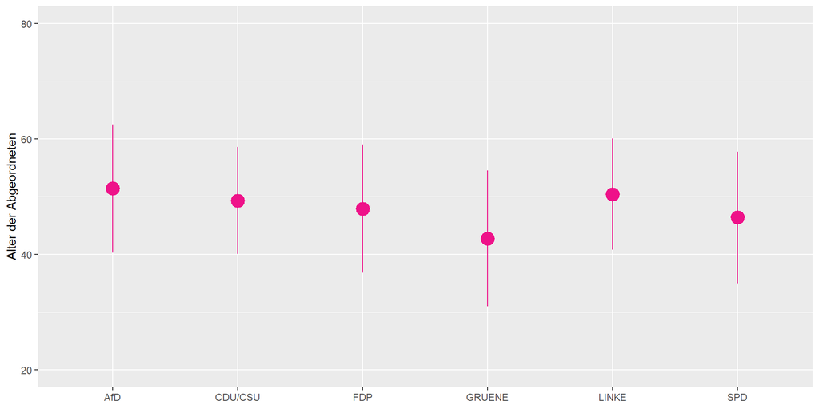

```r
bt %>%
  group_by(partei) %>%
  summarise(mean_alter = mean(alter, na.rm=TRUE),
            std_alter  = sd(alter, na.rm=TRUE)) %>%
  ggplot(aes(x = partei, y = mean_alter,
             ymin = mean_alter - std_alter,
             ymax = mean_alter + std_alter)) +
  geom_pointrange(color = "deeppink2")+
  scale_y_continuous(limits = c(20,80))+
  labs(x = NULL, y = "Alter der Abgeordneten")
```

## Durchschnitt pro Gruppe im Originaldatensatz

```r
bt %>%
  group_by(partei) %>%
  mutate(mean_alter = mean(alter, na.rm=TRUE)) %>%
  select(name, partei, alter, mean_alter) %>%
  head()%>%
  tt(digit = 3) %>% style_tt(fontsize = .5) %>% style_tt(i=0, fontsize = 0.5)
```

| name | partei | alter | mean_alter |
| --- | --- | --- | --- |
| Abdi | SPD | 35 | 46.4 |
| Abel | FDP | 30 | 47.9 |
| Abraham | CDU/CSU | 55 | 49.3 |
| Adler | FDP | 47 | 47.9 |
| Aeffner | GRUENE | 45 | 42.7 |
| Ahmetovic | SPD | 28 | 46.4 |

## `summarise()` vs. `mutate()`

**Sehr wichtig!**

Wenn Sie `group_by()` mit `summarise()` kombinieren, erhalten Sie immer **aggregierte Informationen** – d.h., die Invidualdaten verschwinden. Nutzen Sie hingegen die Kombination `group_by()` und `mutate()` werden zwar die Rechenoperationen oder die Datenumwandlung *auf Gruppenebene durchgeführt*, die Ergebnisse aber **dem Individualdatensatz hinzugefügt**!

Überlegen Sie vorab, was Sie benötigen.

## Übung

Verwenden Sie den Datensatz `bt` und erstellen Sie eine Grafik mit `geom_boxplot()`, die das Alter der Abgeordneten nach Partei zeigt. Fügen Sie der Grafik das Durchschnittsalter in den Fraktionen als rote Punkte hinzu.

## Individual- und Aggregatdaten in einem Plot

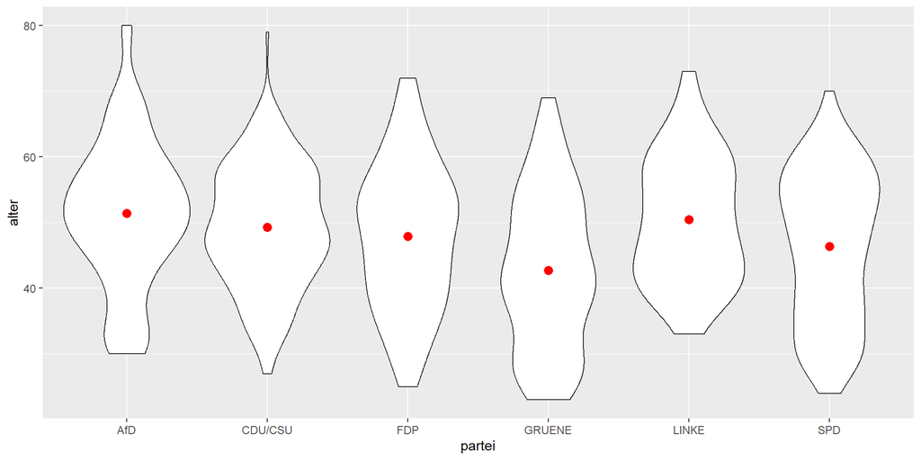

```r
ave_age <- bt %>%
  group_by(partei) %>%
  summarise(mean_alter = mean(alter, na.rm=TRUE)) # erstellt Aggregatdatensatz

ggplot()+
  geom_violin(data = bt, # Individualdatensatz
              aes(x = partei, y = alter)) +
  geom_point(data = ave_age, # Aggregatdatensatz
    aes(x = partei, y = mean_alter), color = "red", size = 3)
```

## … geht auch

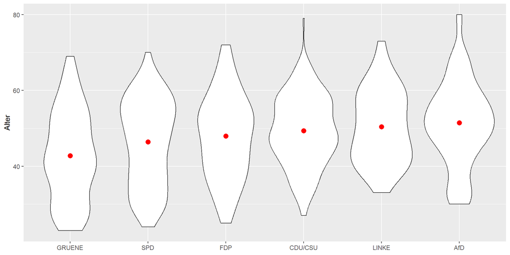

```r
bt %>%
  group_by(partei) %>%
  mutate(mean_alter = mean(alter, na.rm=TRUE)) %>%
  ggplot()+
  geom_violin(aes(x = fct_reorder(partei, mean_alter), y = alter)) +
  geom_point(aes(x =  fct_reorder(partei, mean_alter), y = mean_alter),
              color = "red", size = 3)+
  labs(x = NULL, y = "Alter")
```

## Mehrere Datensätze in `ggplot()`

**Hinweis**

In `ggplot()` können Sie mehrere Datensätze gleichzeitig verwenden, indem Sie in den einzelnen `geom_`-Funktionen die jeweiligen Datensätze angeben. Das ist besonders nützlich, wenn Sie Individual- und Aggregatdaten in einem Plot kombinieren möchten.

# Funktionen

## DRY-Prinzip

Das DRY-Prinzip steht für “**Don’t Repeat Yourself**” und ist ein grundlegendes Prinzip beim Kodieren. Ziel ist es, Redundanzen im Code zu minimieren, um Lesbarkeit und Effizienz zu verbessern und Fehler zu vermeiden.

Die Idee hinter dem DRY-Prinzip ist, dass jedes Wissenselement oder jede Regel in einem System an genau einer Stelle vorhanden sein sollte. Wenn dieselbe Information oder derselbe Code an mehreren Stellen des Skripts wiederholt wird, müssen Änderungen an vielen Stellen vorgenommen werden, was ineffizent und fehleranfällig ist.

Funktionen sind ein Weg, DRY umzusetzen.

## Einführung: Fehleranfälligkeit

```r
df <- tibble(
  a = rnorm(5),
  b = rnorm(5),
  c = rnorm(5),
  d = rnorm(5))

df %>% mutate(
  a = (a - min(a, na.rm = TRUE)) /
    (max(a, na.rm = TRUE) - min(a, na.rm = TRUE)),
  b = (b - min(b, na.rm = TRUE)) /
    (max(b, na.rm = TRUE) - min(a, na.rm = TRUE)),
  c = (c - min(c, na.rm = TRUE)) /
    (max(c, na.rm = TRUE) - min(c, na.rm = TRUE)),
  d = (d - min(d, na.rm = TRUE)) /
    (max(d, na.rm = TRUE) - min(d, na.rm = TRUE))
)
```

Wo liegt der Fehler?<sup>1</sup>

[^1]: Das Beipsiel ist [R for Data Science](https://r4ds.hadley.nz/functions) entnommen.

## Aufbau von Funktionen

Funktionen sind *immer gleich aufgebaut*. Zunächst legen wir einen **Namen** fest, dann sagen wir, dass mit `function()` eine Funktion erstellt wird. Anschließend legen wir in der **runden Klammer** fest, welche Variablen (oder anderes) verwendet werden sollen. In der **geschweiften Klammer** wird anschließend definiert, was die Funktion tun soll.

```r
name_der_funktion <- function(var1){
  ergebnis <- befehl(var1)
  return(ergebnis)
}

name_der_funktion(var1) # wendet die Funktion an
```

## Aufbau von Funktionen

Erstellen Sie nun einen Vektor x, der die Zahlen 1 bis 100 (`x <- c(1:100)`) enthält, und erstellen Sie eine Funktion, die daraus den Mittelwert berechnet.

```r
name_der_funktion <- function(var1){
  ergebnis <- befehl(var1)
  return(ergebnis)
}

name_der_funktion(var1) # wendet die Funktion an
```

## Ein erstes Beispiel

```r
x <- c(1:100)

mtw <- function(var1){
  mtwx <- sum(var1)/length(var1)
  return(mtwx)
  } # muss nicht in einer neuen Zeilen steht, hilft aber beim Lesen.

mtw(x) # jetzt wenden wir die Funktion auf "x" an.
```

```
[1] 50.5
```

## Variablen skalieren

Im nächsten Schritt wollen wir zunächst eine Variable, dann mehrere Variablen zwischen 0 und 1 skalieren. Wir beginnen mit einem ausgedachten Beispiel, bevor wir den Datensatz verwenden.

```r
x <- c(3,5,7,9) # diese Zahlen werden skaliert. Es gibt keine NAs.

x_rs <- ((x - min(x)) / (max(x) - min(x)))

round(x_rs, 2) # Sie erinnern sich an diesen Befehl, nicht wahr?
```

```
[1] 0.00 0.33 0.67 1.00
```

Was müssen wir tun, wenn fehlende Werte vorhanden sind?

## Variablen skalieren

```r
x <- c(3,5,7,9,NA)

x_rs <- ((x - min(x, na.rm = TRUE)) / (max(x, na.rm = TRUE) - min(x, na.rm = TRUE)))

round(x_rs, 2)
```

```
[1] 0.00 0.33 0.67 1.00   NA
```

Schreiben Sie nun eine Funktion mit dem Namen rescale01, die diese Skalierung enthält.

## Skalierungsfunktion

```r
rescale01 <- function(var1){
    (var1 - min(var1, na.rm = TRUE)) /
    (max(var1, na.rm = TRUE) - min(var1, na.rm = TRUE))
}

round(rescale01(x),2)
```

```
[1] 0.00 0.33 0.67 1.00   NA
```

Weitere Tests.

```r
rescale01(c(-10, -7, 0, 4, 10))
```

```
[1] 0.00 0.15 0.50 0.70 1.00
```

```r
rescale01(c(1, 2.8, 3, 4.1, 5))
```

```
[1] 0.000 0.450 0.500 0.775 1.000
```

```r
rescale01(c(-2,-0.5,1,4,7))
```

```
[1] 0.0000000 0.1666667 0.3333333 0.6666667 1.0000000
```

## Echte Daten skalieren

```r
age_rs <- rescale01(ces$age)

summary(age_rs) # dieser Befehl zeigt Kernzahlen eines Vektors an
```

```
   Min. 1st Qu.  Median    Mean 3rd Qu.    Max.
 0.0000  0.2278  0.4304  0.4099  0.5823  1.0000
```

```r
rm(age_rs)
```

## Echte Daten skalieren

Nun fügen wir dem Datensatz neue, reskalierte Variablen hinzu. Wir verwenden die Variablen “age”, “inc6”, “urbancity” und “newsint”.

```r
ces %>%
  mutate(
    age_rs = rescale01(age),
    inc_rs = rescale01(inc6),
    urb_rs = rescale01(urbancity),
    new_rs = rescale01(newsint)) %>%
  names()
```

```
 [1] "caseid"     "age"        "race"       "pid3"       "gndr"
 [6] "region4"    "inc6"       "urbancity"  "edu"        "presvote20"
[11] "newsint"    "CC22_340a"  "CC22_340b"  "CC22_340c"  "CC22_340d"
[16] "CC22_340e"  "CC22_340f"  "CC22_340g"  "CC22_330a"  "CC22_330b"
[21] "CC22_330c"  "CC22_330d"  "CC22_330e"  "CC22_330f"  "age_rs"
[26] "inc_rs"     "urb_rs"     "new_rs"
```

## Ein visueller Eindruck

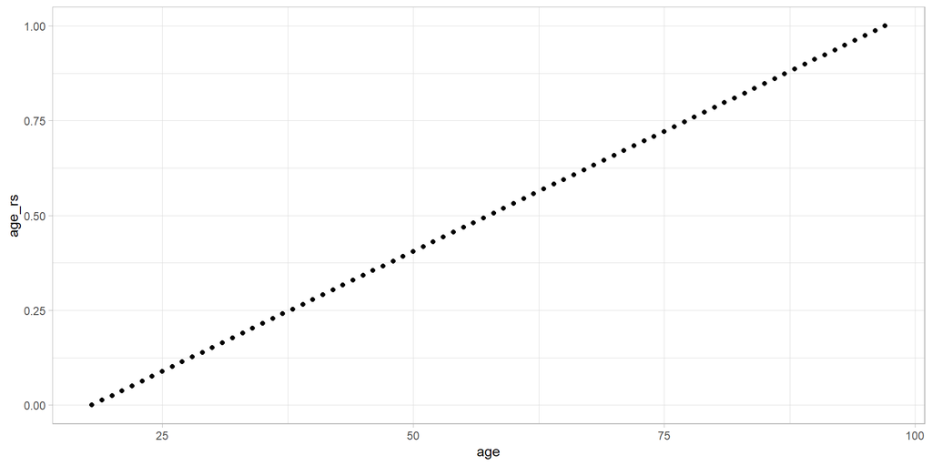

```r
ces %>%
  mutate(
    age_rs = rescale01(age),
    inc_rs = rescale01(inc6),
    urb_rs = rescale01(urbancity),
    new_rs = rescale01(newsint)
  ) %>%
  ggplot(aes(x = age, y = age_rs))+
  geom_point()+ theme_light()
```

## …aber noch zu viele Wiederholungen

Statt die Variablen einzeln zu bearbeiten, verwenden wir `across()`. Die Kombination aus `mutate()` und `across()` erlaubt es, Funktionen auf mehrere Spalten eines Datensatzes anzuwenden:

```r
test <- ces %>% # nicht den Datensatz überschreiben!
  mutate(across(c(age, inc6, urbancity, newsint), rescale01))
```

## Neue Variablen mit `mutate(across())`

```r
ces <- ces %>%
  mutate(across(c(age, inc6, urbancity, newsint), rescale01,
                .names = "{.col}_rs"))
```

Der Befehl `.names` gibt an, wie die neu zu erstellenden Variablen benannt werden. Der neue Name folgt nach dem Gleichheitszeichen. In diesem Fall sagen wir mit `{.col}`, dass der Ursprungsname genommen und mit dem Zusatz `_rs` ergänzt werden soll. Nicht intuitiv, aber sehr nützlich.

## Bestehende Funktionen anwenden

**Tipp**

Statt Spalten/Variablen durch ihre Namen auszuwählen, können wir auch die Auswahloptionen `starts_with()` oder `ends_with()` verwenden – aber nur, **falls die Auswahl damit eindeutig ist**! Weitere Auswahloptionen sind `everything()` oder z.B. `where(is.numeric)`.

To be continued….